# R Notebook

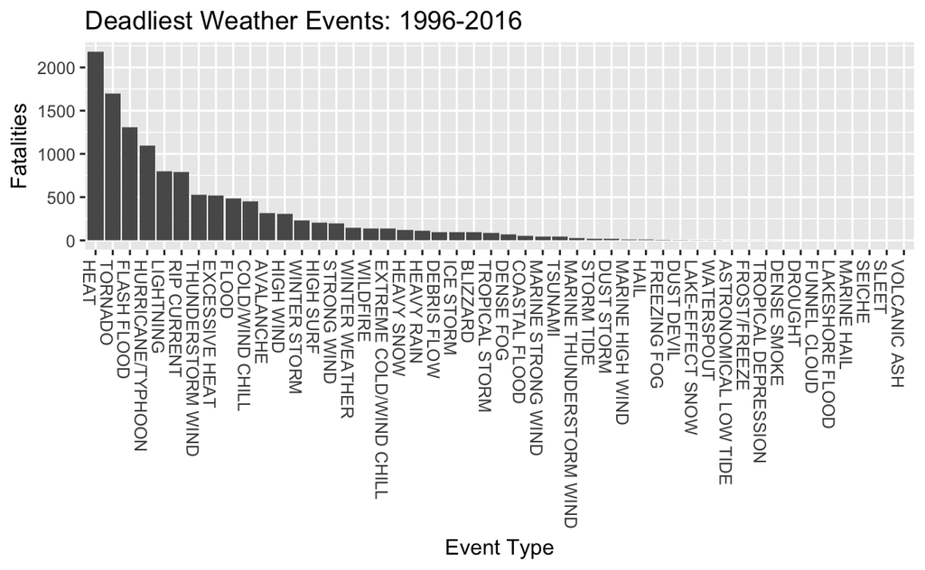

# POISSON

Likelihood: $\mathcal{L}(X|\lambda)\propto\lambda^{n\bar{x}}e^{-n\lambda}$

Jeffreys’ Prior: $\pi(\lambda)=\lambda^{1/2-1}e^{-0\cdot\lambda}$

Posterior: $p(\lambda|X)=\lambda^{n\bar{x}+1/2-1}e^{-n\lambda}$

So the posterior on lambda with non-informative prior is $\mathcal{G}amma(n\bar{x}+1/2,n)$.

```r
set.seed(05092017)
df_tor <- df %>%
  filter(EVENT_TYPE == "TORNADO")
X <- df_tor$DEATHS_DIRECT
alpha <- sum(X) + 1 / 2
beta <- length(X)
B <- 20000
post_lambda <- rgamma(B, alpha, beta)
ci_lambda <- quantile(post_lambda, c(0.025, 0.975))
```

Using the data based off of 20000 posterior samples, we get the posterior median for $\lambda$ is 0.0592 with a 95% credible interval of 0.0565 to 0.0621. The posterior denisty is in the figure below:

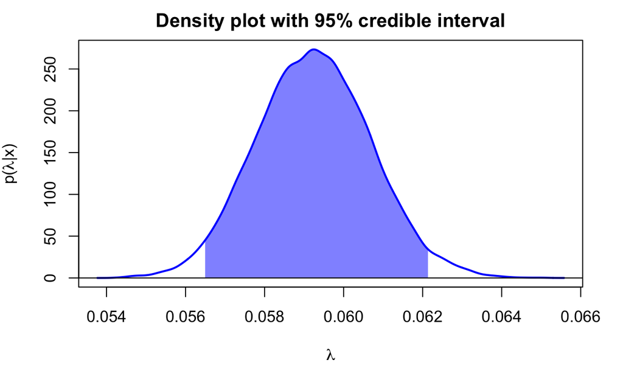

# NEGATIVE BINOMIAL

Likelihood: $\mathcal{L}(X|r,p)=\Bigg[\prod_{i=1}^n\frac{\Gamma(r+x_i)}{\Gamma(r)x_i!}\Bigg]p^{n\bar{x}}(1-p)^{nr}$

Jeffreys’ Prior: $\pi(r,p)=r^{1/2}p^{-1}(1-2)^{-1/2}$

Full Posterior: $p(r,p|X)=\mathcal{L}(X|r,p)\pi(r,p)$

Conditional of p: $p(p|r,X)\propto p^{n\bar{x}-1}(1-p)^{nr+1/2-1}$

Conditional of r: $p(r|p,X)\propto\big[\prod_{i=1}^n\Gamma(r+x_i)\big]\Gamma(r)^{-n}(1-p)^{nr}r^{1/2}$

```r
set.seed(05092017)
X <- df_tor$DEATHS_DIRECT
r <- 1
alpha <- sum(X)
beta <- length(X) * r + 1 / 2
B <- 20000
post_p <- rbeta(B, alpha, beta)
ci_p <- quantile(post_p, c(0.025, 0.975))
```

Using the data based off of 20000 posterior samples, we get the posterior median for $p$ is 0.0559 with a 95% credible interval of 0.0533 to 0.0585. The posterior denisty is in the figure below:

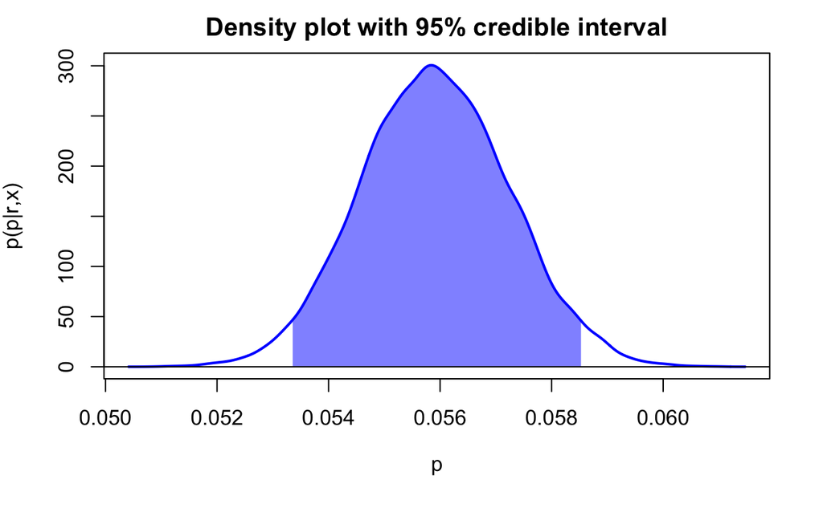